# vishal_writeup

Vishal Juneja

May 13, 2016

### Hierarchichal clustering of President’s speeches

```
## <<DocumentTermMatrix (documents: 224, terms: 24084)>>
## Non-/sparse entries: 301078/5093738
## Sparsity           : 94%
## Maximal term length: 24
## Weighting          : term frequency (tf)
```

```
## <<TermDocumentMatrix (terms: 24084, documents: 224)>>
## Non-/sparse entries: 301078/5093738
## Sparsity           : 94%
## Maximal term length: 24
## Weighting          : term frequency (tf)
```

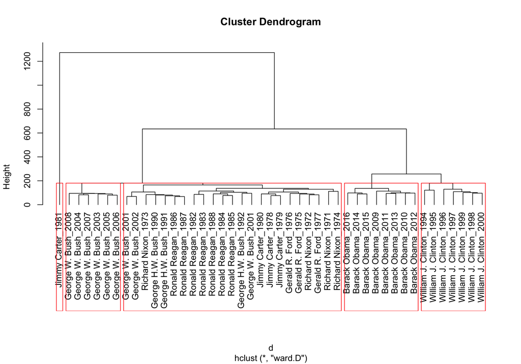

When we observe clusters from a higher level. Barrack Obama and Clinton’s speeches are tagged into the same cluster. Some of Nixon, H.W. Bush, Bush and Reagan’s speeches fall into a single cluster as well. Lastly Jimmy Carter and Gerald Ford’s addresses also seem to be similar in word frequency composition.

The clustering results show that presidents focus on and care about different policy issues and topics in general.

### Comparison of addresses with those of more famous/in-famous personalities

Seeing that our approach can largely distinguish between speech styles and major topics addressed; we thought about comparing the speeches with that of other famous personalities.

#### Hitler

Our aim was to discover which president’s speech style closely resembles that of Adolf Hitler. We took the translated version of Hitler’s speeches over the years: starting from his ascendency to the highest office to his speeches during the world war.

We express closeness or similarity in terms of cosine distances.

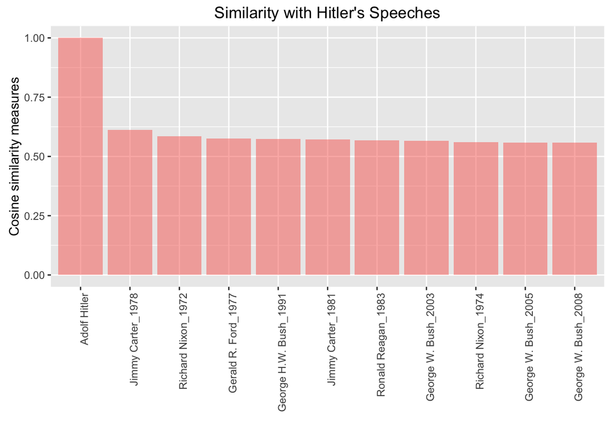

In the above graph we show the top 10 most similar speeches (and speech givers) with those of Hitler’s. As a sanity check Hitler’s speech has a cosine similarity measure of 1 (completely identical) with his own speeches.

We find that most matching speeches were made during war periods e.g. Nixon’s address in 1972 during the Vietnam war, George W. Bush’s speeches in 2003 and 2005 during Afghanistan invasion, George H.W. Bush’s speech in 1991 was again made during the turmoil period in Afghanistan.

#### Gandhi

Mahatma Gandhi as we all know has been a preacher of non-violence and protagonist of peaceful ways for fighting in a just cause. We took Gandhi’s speeches during freedom struggle and after independence and compared them with other presidents.

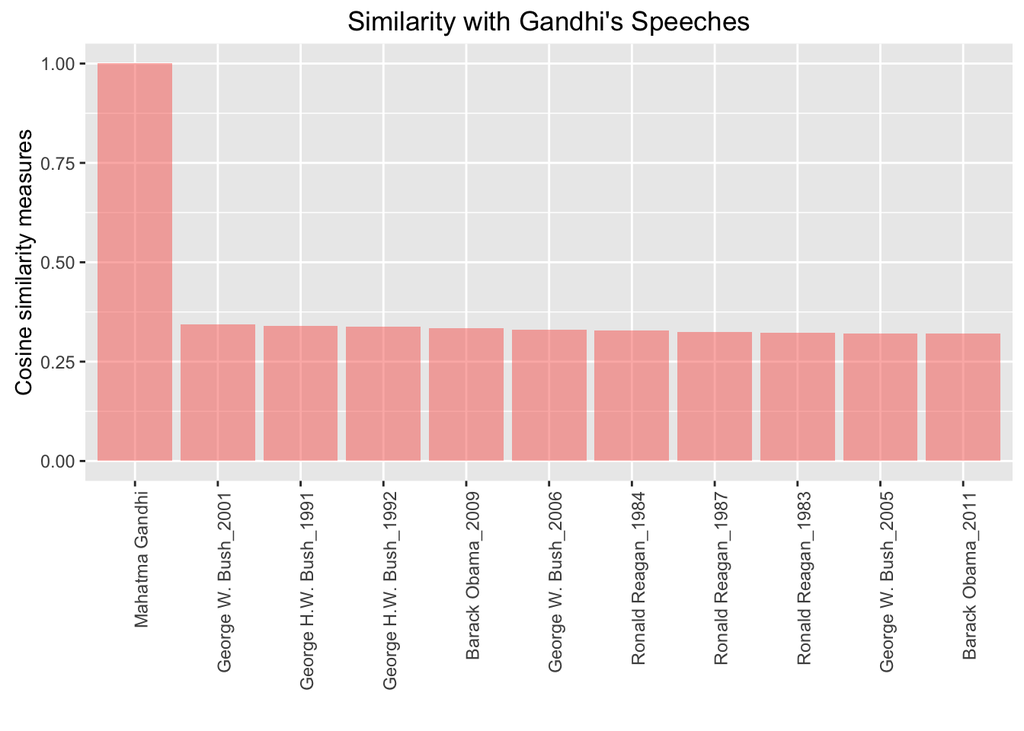

First thing we note is that general similarity measure is very small compared to similarity with Hitler’s speeches (~ 0.30). From the above plot we find that as in Hitler’s case Gandhi’s speeches are similar to George W. Bush, George H.W. Bush’s speeches as well (although Barrack Obama does figures in the top 5). We conjecture that although Bush and Gandhi might both be talking about war, post-war situations and effects of war; their sentiment towards the topics might be different. Note that our similarity measure takes into account only frequency of occurance of words. This means that even though Gandhi and Bush might be talking about the same topics we would not know if there sentiment and opinions about the topics differ.

#### Justin Trudeau

We further took recently elected Canadian president’s address to the nation. Justin Trudeau has been applauded for choosing a very diverse, secular and representative cabinet. His address was seen as being progressive and discussed roadmap for advancing Canada on frontiers of technology and innovation.

[figure not shown]

Other than a few exceptions we note that Justin Trudeau’s speech seem to be similar in spirit with Barrack Obama’s addresses to the nation.